# Predicting Median Home Values

12/09/2019

## Introduction

The goal of this project was to create a prediction model to forecast median home values within a city based upon factors outside of the home’s build.

The observed variables were associated with the location of the home, variables such as;

- Crime Rates
- Median Age
- Income Per Capita
- And more

## Statistical Method

A statistial method had to be chosen in order create the prediction model and determine how to properly and accurately predict median home values within cities.

Once a statisical method was chosen, data was collected in order create a prediction model.

[figure not shown]

## Regression Analysis

The statistical method used for this project was regression analysis. Multiple variables were examined in order to observe their relationship with the chosen dependent varaiable, median home values.

[figure not shown]

## Data Collection

Data was collected through webscraping methods in R from the online platform “AreaVibes.com.”

AreaVibes is a website that ranks the best places to live in the United States. This is accomplished by assigning their trademark “Livability Score” out of 100 to any address, zip code, neighborhood or city within their database.

[figure not shown]

## AreaVibes Cont.

The Livability Scores are determined by various characteristics spanning across 7 categories.

- Amenities
- Cost of Living
- Crime Rates
- Education
- Employment
- Housing
- Weather

AreaVibes collects all of this information from the Federal Bureau of Investigation and United States Census Bureau.

## Data Summary

In the end, the data spanned across

- 5 States
- 1800+ Cities (rows)
- 10+ Location Characteristics Each (columns)

[figure not shown]

## Choosing Independent Variables

Which top 3 variables do you think had the strongest correlations to Median Home Values?

- Population Density
- Crime Rates
- Graduation Rates
- Median Household Income
- Income Per Capita
- Test Scores
- Median Rent
- Median Age
- Graduation Rates

## Choosing Independent Variables Cont.

Which top 3 variables do you think had the strongest correlations to Median Home Values?

- Population Density
- Crime Rates
- Graduation Rates
- **Median Household Income**
- **Income Per Capita**
- Test Scores
- **Median Rent**
- Median Age
- Graduation Rates

## Scatter Plots

- Median Age and Median Home Values showed virtually no linear relationship

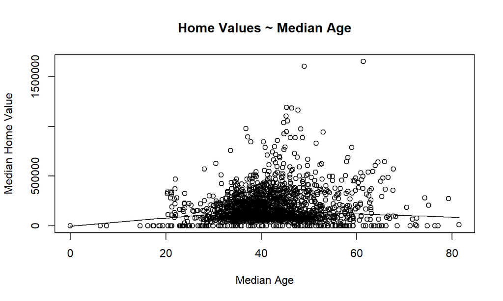

## Scatter Plots

- Income Per Capita and Median Household Incomes suggested stronger linear relationships with Median Home Values

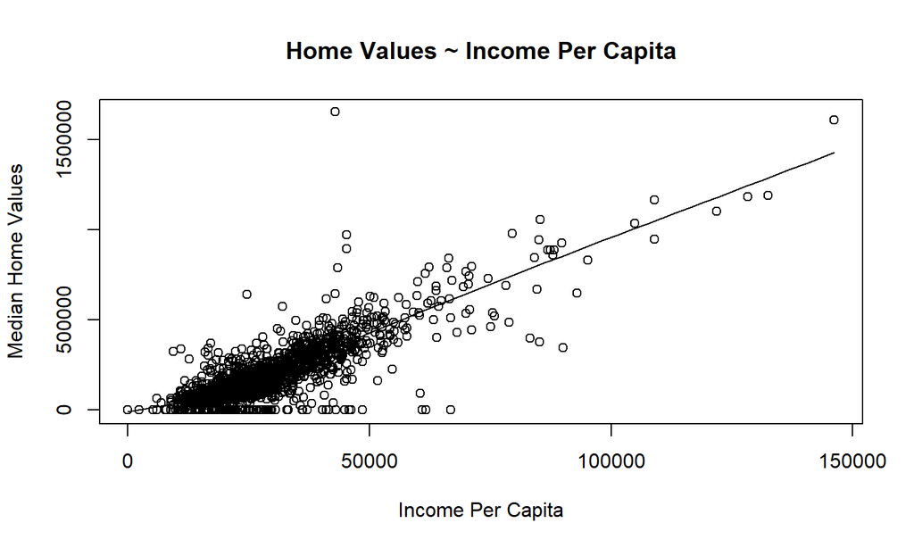

## Scatter Plots

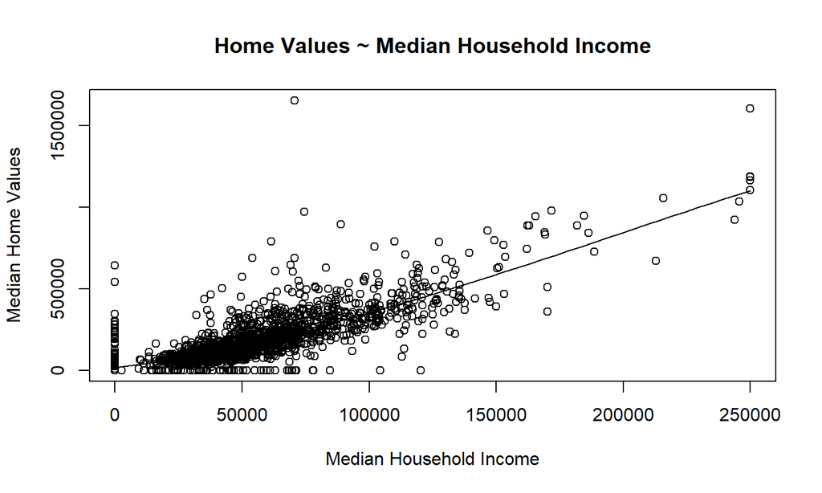

## Scatter Plots

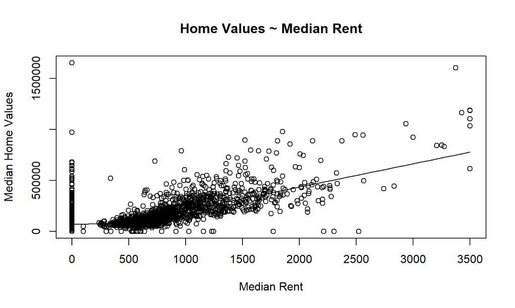

## Data Cleaning

Before creating a prediction model, the data had to first be cleaned in order to remove inconsistencies. Examples of reasons to clean the data

- Instances where median rent was 0 dollars a month
- Test scores were unavailable or "NA

[figure not shown]

## Handling Missing Data

Missing Data, NAs, can be addressed in several different ways. Two data sets were created that utilized two of the possible methods.

- Omitting rows with “NA” values
- Replacing the “NA” values with each column’s median

We will determine which data set leads to a more accurate prediction model.

## Box Plots

- Measure of how well distributed the data is within a data set
- The box in the middle represents the Interquartile Range
- The lines represent the “Minimum” and “Maximum”
- Points outside of those ranges are considered outliers

Box plots are an effective tool for locating outliers within your data. If the outliers are errors, it is important to remove them.

[figure not shown]

## Box Plots

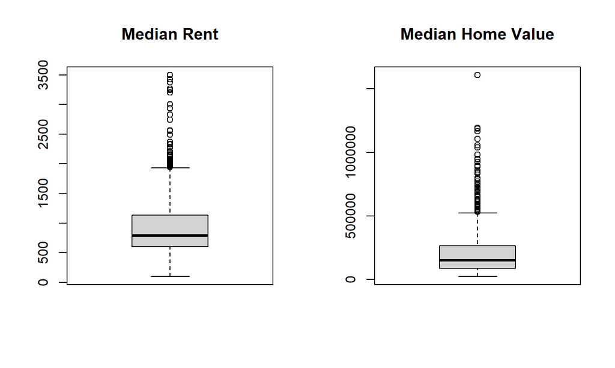

## Before Cleaning the Data

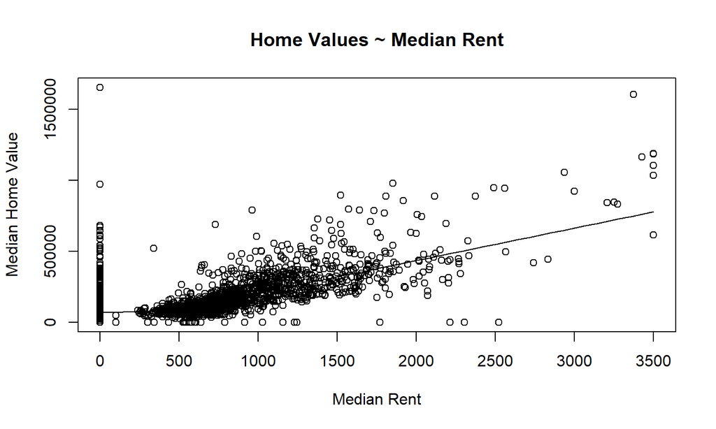

## After Cleaning the Data

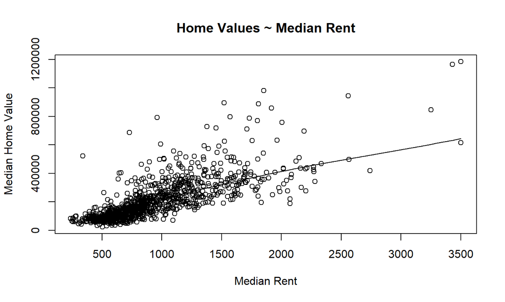

## Correlation Analysis

Each of the independent variables were analyzed after cleaning to confirm their correlation to the independent variable.

Essentially, the following function was performed for each combination of variables.

```r
cor(t.0$Income.Per.Capita,t.0$Median.Home.Value)
```

```
[1] 0.9029469
```

## Correlation Analysis

Based on the analysis, the four variables with the highest correlations are

- Income Per Capita
- Median Household Income
- Median Rent
- Graduation Rates

## Creating the Linear Model

```r
firstlinearMod <- lm(Median.Home.Value ~ Income.Per.Capita +
Median.Rent + Grad.Rates + Median.Household.Income, data=t.0)
```

```r
summary(firstlinearMod)$coefficients
```

```
##                              Estimate   Std. Error    t value     Pr(>|t|)
## (Intercept)             -1.030301e+05 1.804794e+04 -5.7086933 1.473959e-08
## Income.Per.Capita        8.494955e+00 3.624605e-01 23.4369132 2.340527e-98
## Median.Rent              5.907181e+01 7.871976e+00  7.5040630 1.299305e-13
## Grad.Rates              -1.497630e+04 2.648392e+04 -0.5654866 5.718615e-01
## Median.Household.Income  3.952888e-01 1.764138e-01  2.2406908 2.525084e-02
```

```r
summary(firstlinearMod)$adj.r.squared
```

```
## [1] 0.8332114
```

## Creating the Linear Model

Other variables can be added to the model to see if they can explain more of the variance.

For example, let’s see what happens when we replace “Graduation Rates” with “Test Scores” and add “Poverty Rates” to the model.

```r
secondlinearMod <- lm(Median.Home.Value ~ Income.Per.Capita +
Poverty.Rate + Median.Rent + Test.Scores +
Median.Household.Income, data=t.0)
```

```r
summary(secondlinearMod)$coefficients
```

```
##                              Estimate   Std. Error    t value      Pr(>|t|)
## (Intercept)             -2.277360e+05 9.427268e+03 -24.157160 3.258391e-103
## Income.Per.Capita        7.452688e+00 3.278187e-01  22.734177  1.242951e-93
## Poverty.Rate             2.378305e+05 2.304512e+04  10.320211  7.227964e-24
## Median.Rent              6.993293e+01 7.176866e+00   9.744215  1.495004e-21
## Test.Scores              1.638892e+05 1.237370e+04  13.244962  3.465850e-37
## Median.Household.Income  7.647823e-01 1.651631e-01   4.630468  4.097002e-06
```

```r
summary(firstlinearMod)$adj.r.squared
```

```
## [1] 0.8332114
```

```r
summary(secondlinearMod)$adj.r.squared
```

```
## [1] 0.8640903
```

## Predicting with the Linear Model

However, creating a prediction model with the entire dataset will not tell us how the prediction model performs with new data.

The data must be split into two datasets

- Training (80%)
- Testing (20%)

## Prediction Model

A regression function can now be created.

- Income Per Capita = X1
- Median Household Income = X2
- Poverty Rate = X3
- Median Rent = X4
- Test Scores = X5

The function created for the “Omitted” version is:

Y = -2.336e+05 + 7.786e+00X1 + 6.648e-01X2 + 2.494e+05X3 + 1.075e+02X4 + 1.539e+05X5

## Residuals

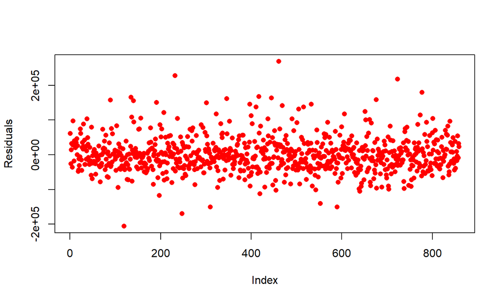

## Residuals

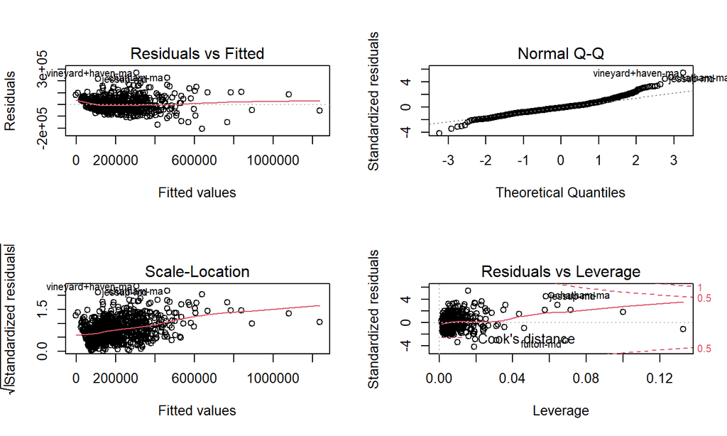

## Example

Example (Athol, MA)

- Income Per Capita = 22206
- Median Household Income = 43619
- Poverty Rate = 0.217
- Median Rent = 661
- Test Scores = 0.45

Y = -2.336e+05 + 7.786e+00(22206) + 6.648e-01(43619) + 2.494e+05(0.217) + 1.075e+02(661) + 1.539e+05(0.45)

## Checking the Model’s Accuracy

The accuracy of the model can be ascertained through analyzing

- Adjusted R^2
- Correlation Accuracy
- Mean Absolute Percentage Error
- Min Max Accuracy

```r
adjusted.R.sq
```

```
[1] 0.8734983
```

```r
correlation_accuracy
```

```
             actuals predicteds
actuals    1.0000000  0.9170053
predicteds 0.9170053  1.0000000
```

```r
Mean.Absolute.Percentage
```

```
[1] 0.2403631
```

```r
min_max_accuracy
```

```
[1] 0.8048386
```

```r
adjusted.R.sq2
```

```
[1] 0.8829101
```

```r
correlation_accuracy2
```

```
             actuals predicteds
actuals    1.0000000  0.9316035
predicteds 0.9316035  1.0000000
```

```r
Mean.Absolute.Percentage2
```

```
[1] 0.2236441
```

```r
min_max_accuracy2
```

```
[1] 0.8225992
```

## Accuracy of Model

The above information suggests the prediction model is accurate and can serve as a prediction model for forecasting Median Home Values within locations.

[figure not shown]

## NAs: Omitted vs Imputation

Between omitting NAs and imputing the median, the data implies that imputing the median created a better performing and more accurate model.

The imputed version was able to retain more rows of data, which can assist in training and testing the machine learning model.

“Omitted” Adjusted R^2

```
## [1] 0.8734983
```

“Imputed” Adjusted R^2

```
## [1] 0.8829101
```

## Questions?

[figure not shown]